# CFA

Maria Jose Beltran

5/10/2021

## Analisis Factorial Exploratorio (Clásico)

Cargamos los paquetes

Importamos los datos. Nos quedamos unicamente con las respuestas a las 33 preguntas de cada alumno (4to curso UIB y Valencia)

```r
datosValencia_T1 <- read_excel("/Users/MariaJose/Desktop/TFG/Encuesta/PID_E_II_control3_T1T2T3_4codificado-1.xlsx", sheet = "control3_T1", range = cell_cols("AN:BT")) %>%
  dplyr::rename(Pregunta_1 = "1. Me resulta facil darme cuenta de las intenciones de las personas que me rodean",
                Pregunta_2 = "2. Me siento bien si los demas se divierten (lo pasan bien)",
                Pregunta_3 = "3. No me pongo triste solo porque un amigo lo este",
                Pregunta_4 = "4. Si un amigo consigue un trabajo muy deseado, me entusiasmo con el",
                Pregunta_5 = "5. Me afecta demasiado ver programas de television donde se muestran los problemas de otras personas",
                Pregunta_6 = "6. Antes de tomar una decision, intento tener en cuenta todos los puntos de vista",
                Pregunta_7 = "7. Rara vez reconozco como se siente una persona con solo mirarla",
                Pregunta_8 = "8. Me afecta poco escuchar desgracias sobre personas desconocidas",
                Pregunta_9 = "9. Me hace ilusion  ver que un amigo nuevo se encuentra a gusto en nuestro grupo",
                Pregunta_10 = "10. Me es dificil entender como se siente una persona ante una situacion que no he vivido",
                Pregunta_11 = "11. Cuando un amigo se ha portado mal conmigo, intento entender los motivos por los que lo ha hecho",
                Pregunta_12 = "12. A menos que se trate de algo muy grave, me cuesta llorar con lo que les sucede a otros",
                Pregunta_13 = "13. Reconozco facilmente cuando alguien esta de mal humor",
                Pregunta_14 = "14. No siempre me doy cuenta cuando la persona que tengo al lado se siente mal",
                Pregunta_15 = "15. Intento ponerme en el lugar de los demas para saber como actuaran",
                Pregunta_16 = "16. Cuando a alguien le sucede algo bueno, siento alegria",
                Pregunta_17 = "17. Si tengo una opinion formada no presto mucha atencion a los argumentos de los demas",
                Pregunta_18 = "18. A veces sufro mas con las desgracias de los demas que ellos mismos",
                Pregunta_19 = "19. Me siento feliz solo con ver felices a otras personas",
                Pregunta_20 = "20. Cuando alguien tiene un problema, intento imaginarme como me sentiria si estuviera en su lugar",
                Pregunta_21 = "21. No siento especial alegria si alguien me cuenta que ha tenido un golpe de suerte",
                Pregunta_22 = "22. Cuando veo que alguien  recibe un regalo no puedo reprimir una sonrisa",
                Pregunta_23 = "23. No puedo evitar llorar con los testimonios de personas desconocidas",
                Pregunta_24 = "24. Cuando conozco gente nueva me doy cuenta de la impresion que se han llevado de mi",
                Pregunta_25 = "25. Cuando mis amigos me cuentan que les va bien, no le doy mucha importancia",
                Pregunta_26 = "26. Encuentro dificil ver las cosas desde el punto de vista de otras personas",
                Pregunta_27 = "27. Entender como se siente otra persona es algo muy facil para mi",
                Pregunta_28 = "28. No soy de esas personas que se deprimen con los problemas de los demas",
                Pregunta_29 = "29. Intento comprender mejor a mis amigos mirando las situaciones desde su perspectiva",
                Pregunta_30 = "30. Me considero una persona fria porque no me conmuevo facilmente",
                Pregunta_31 = "31. Me doy cuenta cuando las personas cercanas a mi estan especialmente contentas, aunque no me hayan contado el motivo",
                Pregunta_32 = "32. Me resulta dificil ponerme en el lugar de personas con las que no estoy de acuerdo",
                Pregunta_33 = "33. Me doy cuenta cuando alguien intenta esconder sus verdaderos sentimientos")
```

```r
datosUIB_T1 <- read_excel("/Users/MariaJose/Desktop/TFG/Encuesta/PID_E_II_int4_T1T2T3_prog_intensivo_4codificado.xlsx", sheet = "EII_int_T1", range = cell_cols("AN:BT")) %>%
  dplyr::rename(Pregunta_1 = '1TECA1', Pregunta_2 = '1TECA2', Pregunta_3 = '1TECA3',Pregunta_4 = '1TECA4', Pregunta_5 = '1TECA5', Pregunta_6 = '1TECA6', Pregunta_7 = '1TECA7', Pregunta_8 = '1TECA8', Pregunta_9 = '1TECA9', Pregunta_10 = '1TECA10', Pregunta_11 =  '1TECA11', Pregunta_12 = '1TECA12', Pregunta_13 = '1TECA13', Pregunta_14 = '1TECA14', Pregunta_15 = '1TECA15', Pregunta_16 = '1TECA16', Pregunta_17 = '1TECA17',Pregunta_18 = '1TECA18', Pregunta_19 = '1TECA19', Pregunta_20 = '1TECA20', Pregunta_21 = '1TECA21',Pregunta_22 = '1TECA22', Pregunta_23 = '1TECA23',Pregunta_24 = '1TECA24', Pregunta_25 = '1TECA25', Pregunta_26 = '1TECA26', Pregunta_27 = '1TECA27', Pregunta_28 = '1TECA28', Pregunta_29 = '1TECA29', Pregunta_30 = '1TECA30', Pregunta_31 = '1TECA31', Pregunta_32 = '1TECA32', Pregunta_33 = '1TECA33')
```

Juntamos los datos

Invertimos el orden de las respuestas para las preguntas necesarias

Agrupamos las preguntas en los 4 factores: Comprension Emocional, Alegria Empatica, Estres Empatico y Adopcion de Perspectivas

Las ordenamos por grupos

```r
T1[T1 == "0"] <- NA
T1 <- na.omit(T1)
T1 = T1[, c(6,11,15,17,20,26,29,32,1,7,10,13,14,24,27,31,33,3,5,8,12,18,23,28,30,2,4,9,16,19,21,22,25)]
```

## CFA

```r
mot_model <- 'AP =~ ap_1 + ap_2 + ap_3 + ap_4 + ap_5 + ap_6 + ap_7 + ap_8
CE =~ ce_1 + ce_2 + ce_3 + ce_4 + ce_5 + ce_6 + ce_7 + ce_8 + ce_9
EE =~ ee_1 + ee_2 + ee_3 + ee_4 + ee_5 + ee_6 + ee_7 + ee_8
AE =~ ae_1 + ae_2 + ae_3 + ae_4 + ae_5 + ae_6 + ae_7 + ae_8'
fitMot <- lavaan::cfa(mot_model, data = T1, ordered = names(T1))
semPaths(fitMot, what = "std", edge.label.cex = 0.7,
edge.color = 1, esize = 1, sizeMan = 4.5, asize = 2.5, intercepts = FALSE, rotation = 4, thresholdColor = "red", mar = c(1, 5, 1.5, 5), fade = FALSE, nCharNodes = 4)
```

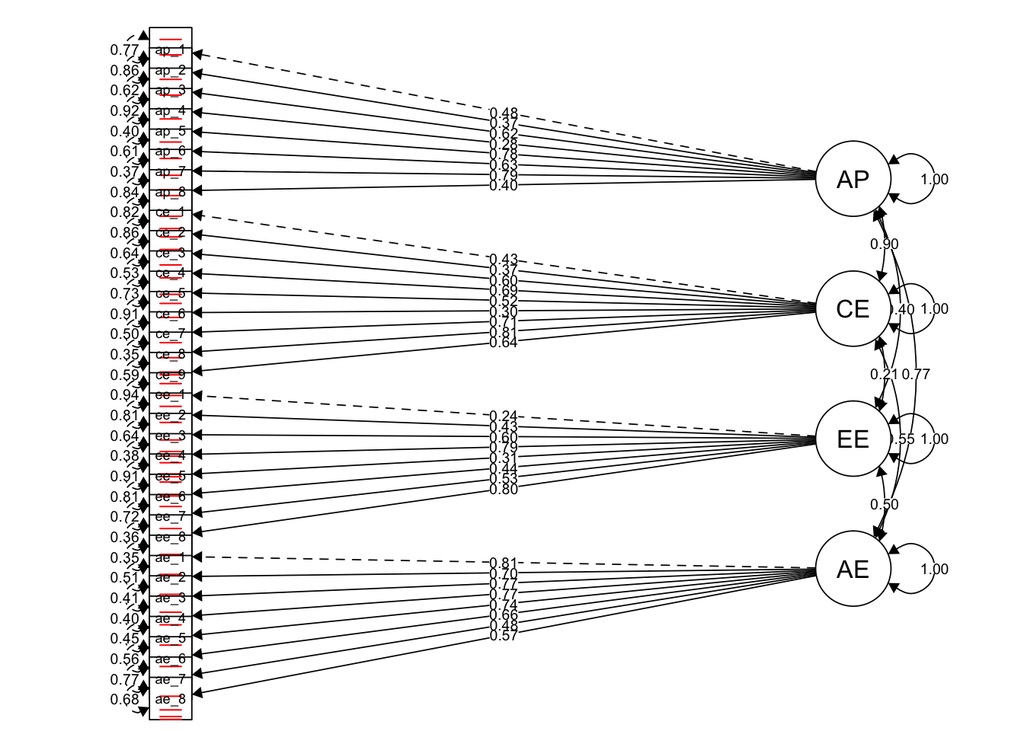

Varianza del error de los indicadores:

```r
inspect(fitMot, what = "est")$theta
```

```
##      ap_1  ap_2  ap_3  ap_4  ap_5  ap_6  ap_7  ap_8  ce_1  ce_2  ce_3  ce_4
## ap_1 0.772
## ap_2 0.000 0.863
## ap_3 0.000 0.000 0.615
## ap_4 0.000 0.000 0.000 0.920
## ap_5 0.000 0.000 0.000 0.000 0.397
## ap_6 0.000 0.000 0.000 0.000 0.000 0.606
## ap_7 0.000 0.000 0.000 0.000 0.000 0.000 0.370
## ap_8 0.000 0.000 0.000 0.000 0.000 0.000 0.000 0.837
## ce_1 0.000 0.000 0.000 0.000 0.000 0.000 0.000 0.000 0.815
## ce_2 0.000 0.000 0.000 0.000 0.000 0.000 0.000 0.000 0.000 0.864
## ce_3 0.000 0.000 0.000 0.000 0.000 0.000 0.000 0.000 0.000 0.000 0.639
## ce_4 0.000 0.000 0.000 0.000 0.000 0.000 0.000 0.000 0.000 0.000 0.000 0.527
## ce_5 0.000 0.000 0.000 0.000 0.000 0.000 0.000 0.000 0.000 0.000 0.000 0.000
## ce_6 0.000 0.000 0.000 0.000 0.000 0.000 0.000 0.000 0.000 0.000 0.000 0.000
## ce_7 0.000 0.000 0.000 0.000 0.000 0.000 0.000 0.000 0.000 0.000 0.000 0.000
## ce_8 0.000 0.000 0.000 0.000 0.000 0.000 0.000 0.000 0.000 0.000 0.000 0.000
## ce_9 0.000 0.000 0.000 0.000 0.000 0.000 0.000 0.000 0.000 0.000 0.000 0.000
## ee_1 0.000 0.000 0.000 0.000 0.000 0.000 0.000 0.000 0.000 0.000 0.000 0.000
## ee_2 0.000 0.000 0.000 0.000 0.000 0.000 0.000 0.000 0.000 0.000 0.000 0.000
## ee_3 0.000 0.000 0.000 0.000 0.000 0.000 0.000 0.000 0.000 0.000 0.000 0.000
## ee_4 0.000 0.000 0.000 0.000 0.000 0.000 0.000 0.000 0.000 0.000 0.000 0.000
## ee_5 0.000 0.000 0.000 0.000 0.000 0.000 0.000 0.000 0.000 0.000 0.000 0.000
## ee_6 0.000 0.000 0.000 0.000 0.000 0.000 0.000 0.000 0.000 0.000 0.000 0.000
## ee_7 0.000 0.000 0.000 0.000 0.000 0.000 0.000 0.000 0.000 0.000 0.000 0.000
## ee_8 0.000 0.000 0.000 0.000 0.000 0.000 0.000 0.000 0.000 0.000 0.000 0.000
## ae_1 0.000 0.000 0.000 0.000 0.000 0.000 0.000 0.000 0.000 0.000 0.000 0.000
## ae_2 0.000 0.000 0.000 0.000 0.000 0.000 0.000 0.000 0.000 0.000 0.000 0.000
## ae_3 0.000 0.000 0.000 0.000 0.000 0.000 0.000 0.000 0.000 0.000 0.000 0.000
## ae_4 0.000 0.000 0.000 0.000 0.000 0.000 0.000 0.000 0.000 0.000 0.000 0.000
## ae_5 0.000 0.000 0.000 0.000 0.000 0.000 0.000 0.000 0.000 0.000 0.000 0.000
## ae_6 0.000 0.000 0.000 0.000 0.000 0.000 0.000 0.000 0.000 0.000 0.000 0.000
## ae_7 0.000 0.000 0.000 0.000 0.000 0.000 0.000 0.000 0.000 0.000 0.000 0.000
## ae_8 0.000 0.000 0.000 0.000 0.000 0.000 0.000 0.000 0.000 0.000 0.000 0.000
##      ce_5  ce_6  ce_7  ce_8  ce_9  ee_1  ee_2  ee_3  ee_4  ee_5  ee_6  ee_7
## ap_1
## ap_2
## ap_3
## ap_4
## ap_5
```

[output cut: 47 more lines]

```
## ee_2
## ee_3
## ee_4
## ee_5
## ee_6
## ee_7
## ee_8 0.363
## ae_1 0.000 0.349
## ae_2 0.000 0.000 0.514
## ae_3 0.000 0.000 0.000 0.414
## ae_4 0.000 0.000 0.000 0.000 0.404
## ae_5 0.000 0.000 0.000 0.000 0.000 0.452
## ae_6 0.000 0.000 0.000 0.000 0.000 0.000 0.559
## ae_7 0.000 0.000 0.000 0.000 0.000 0.000 0.000 0.774
## ae_8 0.000 0.000 0.000 0.000 0.000 0.000 0.000 0.000 0.678
```

Cargas y sus correspondientes versiones estandarizadas:

```r
inspect(fitMot, what = "est")$lambda
```

```
##         AP    CE    EE    AE
## ap_1 1.000 0.000 0.000 0.000
## ap_2 0.776 0.000 0.000 0.000
## ap_3 1.300 0.000 0.000 0.000
## ap_4 0.592 0.000 0.000 0.000
## ap_5 1.627 0.000 0.000 0.000
## ap_6 1.315 0.000 0.000 0.000
## ap_7 1.663 0.000 0.000 0.000
## ap_8 0.847 0.000 0.000 0.000
## ce_1 0.000 1.000 0.000 0.000
## ce_2 0.000 0.859 0.000 0.000
## ce_3 0.000 1.397 0.000 0.000
## ce_4 0.000 1.599 0.000 0.000
## ce_5 0.000 1.199 0.000 0.000
## ce_6 0.000 0.687 0.000 0.000
## ce_7 0.000 1.648 0.000 0.000
## ce_8 0.000 1.873 0.000 0.000
## ce_9 0.000 1.491 0.000 0.000
## ee_1 0.000 0.000 1.000 0.000
## ee_2 0.000 0.000 1.831 0.000
## ee_3 0.000 0.000 2.531 0.000
## ee_4 0.000 0.000 3.330 0.000
## ee_5 0.000 0.000 1.304 0.000
## ee_6 0.000 0.000 1.862 0.000
## ee_7 0.000 0.000 2.247 0.000
## ee_8 0.000 0.000 3.382 0.000
## ae_1 0.000 0.000 0.000 1.000
## ae_2 0.000 0.000 0.000 0.864
## ae_3 0.000 0.000 0.000 0.949
## ae_4 0.000 0.000 0.000 0.957
## ae_5 0.000 0.000 0.000 0.917
## ae_6 0.000 0.000 0.000 0.823
## ae_7 0.000 0.000 0.000 0.589
## ae_8 0.000 0.000 0.000 0.703
```

```r
inspect(fitMot, what = "std")$lambda
```

```
##         AP    CE    EE    AE
## ap_1 0.477 0.000 0.000 0.000
## ap_2 0.371 0.000 0.000 0.000
## ap_3 0.620 0.000 0.000 0.000
## ap_4 0.283 0.000 0.000 0.000
## ap_5 0.777 0.000 0.000 0.000
## ap_6 0.627 0.000 0.000 0.000
## ap_7 0.794 0.000 0.000 0.000
## ap_8 0.404 0.000 0.000 0.000
## ce_1 0.000 0.430 0.000 0.000
## ce_2 0.000 0.369 0.000 0.000
## ce_3 0.000 0.601 0.000 0.000
## ce_4 0.000 0.688 0.000 0.000
## ce_5 0.000 0.516 0.000 0.000
## ce_6 0.000 0.296 0.000 0.000
## ce_7 0.000 0.709 0.000 0.000
## ce_8 0.000 0.806 0.000 0.000
## ce_9 0.000 0.641 0.000 0.000
## ee_1 0.000 0.000 0.236 0.000
## ee_2 0.000 0.000 0.432 0.000
## ee_3 0.000 0.000 0.597 0.000
## ee_4 0.000 0.000 0.786 0.000
## ee_5 0.000 0.000 0.308 0.000
## ee_6 0.000 0.000 0.439 0.000
## ee_7 0.000 0.000 0.530 0.000
## ee_8 0.000 0.000 0.798 0.000
## ae_1 0.000 0.000 0.000 0.807
## ae_2 0.000 0.000 0.000 0.697
## ae_3 0.000 0.000 0.000 0.766
## ae_4 0.000 0.000 0.000 0.772
## ae_5 0.000 0.000 0.000 0.740
## ae_6 0.000 0.000 0.000 0.664
## ae_7 0.000 0.000 0.000 0.475
## ae_8 0.000 0.000 0.000 0.568
```

Matriz de covarianza de la variable latente:

```r
inspect(fitMot, what = "est")$psi
```

```
##    AP    CE    EE    AE
## AP 0.228
## CE 0.185 0.185
## EE 0.045 0.021 0.056
## AE 0.296 0.192 0.096 0.651
```

```r
inspect(fitMot, what = "std")$psi #standardized version (correlation matrix)
```

```
##    AP    CE    EE    AE
## AP 1.000
## CE 0.901 1.000
## EE 0.400 0.205 1.000
## AE 0.768 0.553 0.503 1.000
```

Las pruebas expl??citas de si las cargas (y otros par??metros del modelo) difieren de 0, incluidos los IC del 95%, se pueden calcular a trav??s de:

```r
parameterEstimates(fitMot, standardized = TRUE)
```

```
##      lhs  op  rhs    est    se      z pvalue ci.lower ci.upper std.lv std.all
## 1     AP  =~ ap_1  1.000 0.000     NA     NA    1.000    1.000  0.477   0.477
## 2     AP  =~ ap_2  0.776 0.167  4.663  0.000    0.450    1.103  0.371   0.371
## 3     AP  =~ ap_3  1.300 0.195  6.658  0.000    0.917    1.683  0.620   0.620
## 4     AP  =~ ap_4  0.592 0.176  3.370  0.001    0.248    0.936  0.283   0.283
## 5     AP  =~ ap_5  1.627 0.231  7.054  0.000    1.175    2.079  0.777   0.777
## 6     AP  =~ ap_6  1.315 0.210  6.245  0.000    0.902    1.727  0.627   0.627
## 7     AP  =~ ap_7  1.663 0.241  6.909  0.000    1.191    2.135  0.794   0.794
## 8     AP  =~ ap_8  0.847 0.209  4.050  0.000    0.437    1.257  0.404   0.404
## 9     CE  =~ ce_1  1.000 0.000     NA     NA    1.000    1.000  0.430   0.430
## 10    CE  =~ ce_2  0.859 0.225  3.816  0.000    0.418    1.300  0.369   0.369
## 11    CE  =~ ce_3  1.397 0.288  4.844  0.000    0.832    1.962  0.601   0.601
## 12    CE  =~ ce_4  1.599 0.312  5.118  0.000    0.987    2.212  0.688   0.688
## 13    CE  =~ ce_5  1.199 0.258  4.638  0.000    0.692    1.705  0.516   0.516
## 14    CE  =~ ce_6  0.687 0.187  3.679  0.000    0.321    1.053  0.296   0.296
```

[output cut: 533 more lines]

Las pruebas de significancia se llevan a cabo sobre los par??metros no estandarizados. El argumento standardized = TRUE agrega las columnas std.lv y std.all, indicando estimaciones estandarizadas cuando solo las variables latentes est??n estandarizadas, y estimaciones estandarizadas cuando las variables latentes y observadas est??n estandarizadas, respectivamente.

Para obtener el resultado completo del modelo, incluidas las medidas de bondad de ajuste:

```r
summary(fitMot, standardized = TRUE, fit.measures = TRUE)
```

```
## lavaan 0.6-7 ended normally after 89 iterations
##
##   Estimator                                       DWLS
##   Optimization method                           NLMINB
##   Number of free parameters                        166
##
##   Number of observations                           121
##
## Model Test User Model:
##                                               Standard      Robust
##   Test Statistic                              1241.033     917.726
##   Degrees of freedom                               489         489
##   P-value (Chi-square)                           0.000       0.000
##   Scaling correction factor                                  2.085
##   Shift parameter                                          322.396
##        simple second-order correction
##
## Model Test Baseline Model:
##
##   Test statistic                              8582.259    2886.750
##   Degrees of freedom                               528         528
##   P-value                                        0.000       0.000
##   Scaling correction factor                                  3.415
##
## User Model versus Baseline Model:
##
##   Comparative Fit Index (CFI)                    0.907       0.818
##   Tucker-Lewis Index (TLI)                       0.899       0.804
##
##   Robust Comparative Fit Index (CFI)                            NA
##   Robust Tucker-Lewis Index (TLI)                               NA
##
## Root Mean Square Error of Approximation:
##
##   RMSEA                                          0.113       0.085
##   90 Percent confidence interval - lower         0.105       0.077
##   90 Percent confidence interval - upper         0.121       0.094
##   P-value RMSEA <= 0.05                          0.000       0.000
##
##   Robust RMSEA                                                  NA
```

[output cut: 295 more lines]

```
##     ee_2              1.000                               1.000    1.000
##     ee_3              1.000                               1.000    1.000
##     ee_4              1.000                               1.000    1.000
##     ee_5              1.000                               1.000    1.000
##     ee_6              1.000                               1.000    1.000
##     ee_7              1.000                               1.000    1.000
##     ee_8              1.000                               1.000    1.000
##     ae_1              1.000                               1.000    1.000
##     ae_2              1.000                               1.000    1.000
##     ae_3              1.000                               1.000    1.000
##     ae_4              1.000                               1.000    1.000
##     ae_5              1.000                               1.000    1.000
##     ae_6              1.000                               1.000    1.000
##     ae_7              1.000                               1.000    1.000
##     ae_8              1.000                               1.000    1.000
```

```r
parameterEstimates(fitMot)
```

```
##      lhs  op  rhs    est    se      z pvalue ci.lower ci.upper
## 1     AP  =~ ap_1  1.000 0.000     NA     NA    1.000    1.000
## 2     AP  =~ ap_2  0.776 0.167  4.663  0.000    0.450    1.103
## 3     AP  =~ ap_3  1.300 0.195  6.658  0.000    0.917    1.683
## 4     AP  =~ ap_4  0.592 0.176  3.370  0.001    0.248    0.936
## 5     AP  =~ ap_5  1.627 0.231  7.054  0.000    1.175    2.079
## 6     AP  =~ ap_6  1.315 0.210  6.245  0.000    0.902    1.727
## 7     AP  =~ ap_7  1.663 0.241  6.909  0.000    1.191    2.135
## 8     AP  =~ ap_8  0.847 0.209  4.050  0.000    0.437    1.257
## 9     CE  =~ ce_1  1.000 0.000     NA     NA    1.000    1.000
## 10    CE  =~ ce_2  0.859 0.225  3.816  0.000    0.418    1.300
## 11    CE  =~ ce_3  1.397 0.288  4.844  0.000    0.832    1.962
## 12    CE  =~ ce_4  1.599 0.312  5.118  0.000    0.987    2.212
## 13    CE  =~ ce_5  1.199 0.258  4.638  0.000    0.692    1.705
## 14    CE  =~ ce_6  0.687 0.187  3.679  0.000    0.321    1.053
```

[output cut: 259 more lines]